# week 9: advanced methods

gaussian processes

```r
library(tidyverse)
library(psych)
library(cowplot)
library(patchwork)
library(here)
library(brms)
library(tidybayes)
library(scales) #for some plotting features
library(invgamma) # new distribution
```

## continuous categories

Thus far, our MLMs have grouped observations within essentially nominal categories – even when we use numbers, we’re treating these categories as unordered and discrete. A participant id is just a label for a unique “thing”. In these models, partial pooling does double duty – it improves accuracy by borrowing information from other groups but estimates variation across groups.

But consider other types of grouping that are not so distinct – McElreath shows examples using spatial distance, but also consider time or age. Individuals of the same age share some exposure (cultural trends, political and historical events, even climate); they also share exposure with people of similar ages. And even though we assign labels to generations, guessing the similarity between two people is probably better done by the differences in their ages rather than whether they share a generational label.

In this case, it wouldn’t make as much sense to fit a separate intercept for individuals of the same age, because the model would borrow equally from all other groups. Instead, we would rather the model borrow information in proportion to the closeness of other groups (e.g., intercepts for 27-year-olds should be more informed by data from 28- and 26-year-olds than 67-year-olds).

The general approach to this is known as **GAUSSIAN PROCESS REGRESSION**.

## research questions

Gaussian processes can be useful for answering questions like:

- How do effects vary smoothly across continuous variables?
- What is the functional relationship between predictors and outcomes when the form is unknown?
- How do temporal or spatial factors influence outcomes?
- What are the similarities between observations based on multiple dimensions?
- How can we make predictions with appropriate uncertainty for new, unseen values?
- How do multiple signals interact in complex, non-linear ways?
- What’s the underlying pattern when we have noisy measurements?

## formal definition

From the `brms` [manual](https://cran.r-project.org/web/packages/brms/brms.pdf#page=105.08):

A GP is a stochastic process, which describes the relation between one or more predictors $x = (x_1, ..., x_d)$ and a response $f(x)$, where $d$ is the number of predictors. A GP is the generalization of the multivariate normal distribution to an infinite number of dimensions. Thus, it can be interpreted as a prior over functions. The values of $f()$ at any finite set of locations are jointly multivariate normal, with a covariance matrix defined by the covariance kernal $k_p (x_i,x_j)$, where $p$ is the vector of parameters of the GP:

$$f(x_1),...,f(x_n) \sim \text{MVN}(0, (k_p(x_i,x_j))^n_{i,j=1})$$

The smoothness and general behavior of the function $f$ depends only on the choice of the covariance kernel.

## kernals

The smoothness and general behavior of the function $f$ depends only on the choice of the covariance kernel. In plain English, a kernel is like a “relationship measurer” between any two points in your data. It answers the question: “If I know the value at point A, how much does that tell me about the value at point B?”

The kernel determines how the influence spreads across your data. If two points are close together according to the kernel, their values will be similar. If two points are far apart, their values will be uncorrelated (but not necessarily far apart).

Different kernels create different patterns of relationships. For example:

- Some kernels make smooth, gentle transitions between points
- Others allow for more abrupt changes
- Some might say that periodic patterns exist (like seasonal effects)

The mathematical formula of the kernel determines exactly how this similarity decays with distance, time, or whatever dimension you’re working with.

Currently there are four available kernels in `brms` (in order from smoothest to roughest):

- `exp_quad`: exponentiated quadratic
- `matern52`: Matern 5/2
- `matern32`: Matern 3/2
- `exponential`: exponential

(Details about the kernels from the [Stan manual](https://mc-stan.org/docs/functions-reference/matrix_operations.html#gaussian-process-covariance-functions).)

### exponentiated quadratic

With magnitude $\sigma$ and length scale $l$, the exponentiated quadratic kernel is:

$$k(x_i, x_j) = \sigma^2\text{exp}(-\frac{|x_i-x_j|^2}{2l^2})$$
* Think of it as creating very gentle hills and valleys - no sudden jumps or sharp corners * Influence between points drops off quickly (like a bell curve) * If you know the value at age 25, it gives you strong information about age 24 and 26, moderate information about age 22 and 28, and very little about age 15 or 35 * Best for processes you believe are inherently smooth and continuous * Example: Physical growth patterns in children might follow this kind of smooth curve

### Matern 3/2

This creates somewhat rougher patterns than the exponentiated quadratic.

With magnitude $\sigma$ and length scale $l$, the Matern 3/2 kernel is:

$$k(x_i,x_j) = \sigma^2(1 + \frac{\sqrt{3}|x_i-x_j|}{l})\text{exp}(- \frac{\sqrt{3}|x_i-x_j|}{l})$$

- Still creates continuous curves, but allows for more wiggles and variations
- Points still influence their neighbors, but the influence dies off more quickly
- If two points are very close, they’re still highly related, but medium-distance points have less relationship
- Good for processes that are continuous but have some natural variability
- Example: Income patterns across adjacent neighborhoods might follow this pattern - generally related but with some local variations

### Matern 5/2

This sits between the very smooth `exp_quad` and the rougher `matern32`.

$$k(x_i,x_j) = \sigma^2(1 + \frac{\sqrt{5}|x_i-x_j|}{l}+ \frac{\sqrt{5}|x_i-x_j|^2}{3l^2})\text{exp}(- \frac{\sqrt{5}|x_i-x_j|}{l})$$

- Allows for more flexibility than `exp_quad` while still maintaining good continuity
- Example: Environmental factors like temperature across a landscape might follow this pattern, with generally smooth transitions but allowing for some local variations

### exponential

This is the roughest of the four kernels.

With magnitude $\sigma$ and length scale $l$, the exponential kernel is:

$$k(x_i, x_j) = \sigma^2\text{exp}(-\frac{|x_i-x_j|}{l})$$

- Creates patterns that can change more abruptly
- The influence between points drops off very quickly with distance
- Neighboring points still have relationship, but it weakens more rapidly than with other kernels
- Good for processes where you expect more abrupt changes or less smoothness
- Example: Opinion shifts across different age groups during times of rapid social change might follow this pattern, with sharper transitions between cohorts

## example: data

Data come from a 26-wave (every 2 weeks) study of political attitudes ([Brandt et al., 2021](https://openpsychologydata.metajnl.com/articles/10.5334/jopd.54#3-dataset-description)).

[Download the csv file here](https://osf.io/782ez).

```r
d <- read_csv(here("files/data/external_data/yllanon.csv"))
d = d |> filter(wave == 1 & !is.na(age))
# %>%
#   select(id, wave, age, gender, ethnic, edu,
#          health, econ, crime, imm, vaccines, ideo)
# rethinking::precis(d)
```

Should federal spending on defense be increased, decreased, or kept the same?

- 1 - Greatly decrease
- 7 - Greatly increase

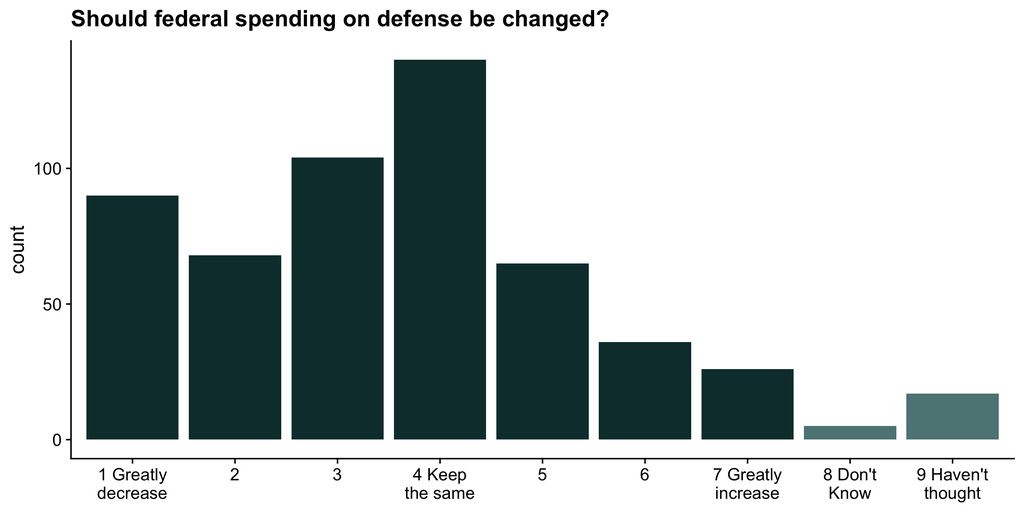

```r
d %>%
  count(def) %>%
  mutate(
    col = ifelse(def >7, "1","2"),
    def = factor(def,
                      levels=c(1:9),
                      labels = c("1\nGreatly decrease", "2", "3", "4\nKeep the same", "5", "6", "7\nGreatly increase", "8\n Don't Know", "9\n Haven't thought"))) %>%
  ggplot(aes(x=def, y=n)) +
  geom_col(aes(fill=col)) +
  scale_x_discrete(labels = label_wrap(10)) +
  labs(title = "Should federal spending on defense be changed?",
       x=NULL,
       y = "count") +
  theme(legend.position = "none")
```

### some data cleaning

Let’s remove those values on the variable that are not part of our Likert scale.

```r
d = filter(d, def <= 7)
```

We might suspect that people of similar ages have similar opinions on a question like this. But would we say that age has a linear effect?

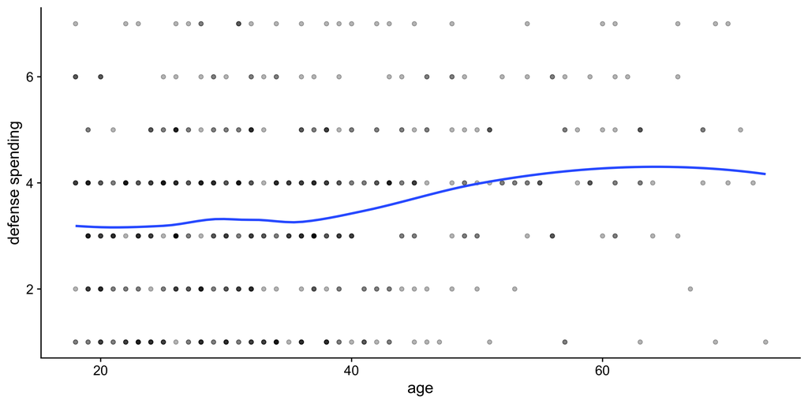

```r
d |>
  ggplot( aes(x=age, y=def) ) +
  geom_point(alpha=.3) +
  geom_smooth(se=F) +
  labs(x="age", y="defense spending")
```

### model 1: intercept only

Let’s say we’re interested in studying how time and age impact the responses to this question. We’ll build up our models from most simple to most complex.

$$\begin{align*}
R_{i} &\sim \text{Categorical}(p) \\
\text{logit}(p) &= \alpha - \phi \\
\phi &= 0 \\
\alpha &\sim \text{Normal}(0, 1.5) \\
\end{align*}$$

```r
m1 <- brm(
  data = d,
  family = cumulative,
  def ~ 1,
  prior = c( prior(normal(0, 1.5), class = Intercept) ),
  iter=2000, warmup=1000, seed=3, cores=4,
  file = here("files/models/m91.1")
)
```

```r
m1
```

```
 Family: cumulative
  Links: mu = logit; disc = identity
Formula: def ~ 1
   Data: d (Number of observations: 529)
  Draws: 4 chains, each with iter = 2000; warmup = 1000; thin = 1;
         total post-warmup draws = 4000

Regression Coefficients:
             Estimate Est.Error l-95% CI u-95% CI Rhat Bulk_ESS Tail_ESS
Intercept[1]    -1.59      0.11    -1.82    -1.37 1.00     3109     2689
Intercept[2]    -0.86      0.09    -1.04    -0.68 1.00     4144     3091
Intercept[3]    -0.03      0.09    -0.20     0.14 1.00     4492     3409
Intercept[4]     1.13      0.10     0.94     1.34 1.00     4642     3428
Intercept[5]     1.99      0.13     1.73     2.25 1.00     5056     3572
Intercept[6]     2.93      0.19     2.57     3.33 1.00     5240     3116

Further Distributional Parameters:
     Estimate Est.Error l-95% CI u-95% CI Rhat Bulk_ESS Tail_ESS
disc     1.00      0.00     1.00     1.00   NA       NA       NA

Draws were sampled using sampling(NUTS). For each parameter, Bulk_ESS
and Tail_ESS are effective sample size measures, and Rhat is the potential
scale reduction factor on split chains (at convergence, Rhat = 1).
```

### model 2: age as a linear predictor

```r
m2 <- brm(
  data = d,
  family = cumulative,
  def ~ 1 + age,
  prior = c( prior(normal(0, 1.5), class = Intercept),
             prior(normal(0, 1),   class = b)),
  iter=5000, warmup=1000, seed=3, cores=4,
  file = here("files/models/m91.2")
)
```

```r
m2
```

```
 Family: cumulative
  Links: mu = logit; disc = identity
Formula: def ~ 1 + age
   Data: d (Number of observations: 529)
  Draws: 4 chains, each with iter = 5000; warmup = 1000; thin = 1;
         total post-warmup draws = 16000

Regression Coefficients:
             Estimate Est.Error l-95% CI u-95% CI Rhat Bulk_ESS Tail_ESS
Intercept[1]    -0.54      0.24    -1.00    -0.06 1.00    21384    12833
Intercept[2]     0.22      0.23    -0.24     0.67 1.00    23937    12552
Intercept[3]     1.08      0.24     0.62     1.55 1.00    21984    12201
Intercept[4]     2.28      0.25     1.79     2.79 1.00    20214    12964
Intercept[5]     3.17      0.27     2.64     3.71 1.00    19651    12984
Intercept[6]     4.12      0.31     3.51     4.74 1.00    20335    13038
age              0.03      0.01     0.02     0.04 1.00    21477    12271

Further Distributional Parameters:
     Estimate Est.Error l-95% CI u-95% CI Rhat Bulk_ESS Tail_ESS
disc     1.00      0.00     1.00     1.00   NA       NA       NA

Draws were sampled using sampling(NUTS). For each parameter, Bulk_ESS
and Tail_ESS are effective sample size measures, and Rhat is the potential
scale reduction factor on split chains (at convergence, Rhat = 1).
```

### model 3: gaussian process on age

```r
m3 <- brm(
  data = d,
  family = cumulative,
  def ~ 1 + gp(age, cov = "exp_quad", scale = F),
  prior = c( prior(normal(0, 1.5),    class=Intercept),
             prior(inv_gamma(2.5, 3), class=lscale, coef = gpage),
             prior(exponential(1),    class=sdgp, coef = gpage)),
  iter=5000, warmup=1000, seed=3, cores=4,
  file = here("files/models/m91.3")
)
```

```r
m3
```

```
 Family: cumulative
  Links: mu = logit; disc = identity
Formula: def ~ 1 + gp(age, cov = "exp_quad", scale = F)
   Data: d (Number of observations: 529)
  Draws: 4 chains, each with iter = 5000; warmup = 1000; thin = 1;
         total post-warmup draws = 16000

Gaussian Process Hyperparameters:
              Estimate Est.Error l-95% CI u-95% CI Rhat Bulk_ESS Tail_ESS
sdgp(gpage)       0.63      0.31     0.26     1.51 1.00     4794     3120
lscale(gpage)    11.99      8.84     2.38    34.55 1.00     1913     3434

Regression Coefficients:
             Estimate Est.Error l-95% CI u-95% CI Rhat Bulk_ESS Tail_ESS
Intercept[1]    -2.01      0.36    -2.84    -1.37 1.00     5063     3825
Intercept[2]    -1.26      0.35    -2.07    -0.63 1.00     5438     3817
Intercept[3]    -0.40      0.35    -1.20     0.23 1.00     5349     3817
Intercept[4]     0.81      0.35     0.01     1.44 1.00     5782     3874
Intercept[5]     1.69      0.36     0.89     2.35 1.00     5838     3838
Intercept[6]     2.65      0.39     1.81     3.36 1.00     6088     3897

Further Distributional Parameters:
     Estimate Est.Error l-95% CI u-95% CI Rhat Bulk_ESS Tail_ESS
disc     1.00      0.00     1.00     1.00   NA       NA       NA

Draws were sampled using sampling(NUTS). For each parameter, Bulk_ESS
and Tail_ESS are effective sample size measures, and Rhat is the potential
scale reduction factor on split chains (at convergence, Rhat = 1).
```

As a reminder, the kernel formula for our GP is

$$k(x_i, x_j) = \sigma^2\text{exp}(-\frac{|x_i-x_j|^2}{2l^2})$$

The value $|x_i-x_j|^2$ is the absolute squared distance between two values. That means, the two values estimated in our model are $\sigma$ and $l$. What do each of these mean?

Let’s start with $l$: The value of $1/(2\times l^2)$ is equal to $\rho$. So we can rewrite the equation as

$$k(x_i, x_j) = \sigma^2\text{exp}(-\rho|x_i-x_j|^2)$$
In other words, the covariance between two values is declines exponentially with the squared distance between them.

The remaining piece, $\sigma^2$ is the maximum covariance between any two values.

I used an `invgamma` distribution for as my prior for $l$ and an expoential distribution as the prior for $\sigma$. Here’s what that looks like:

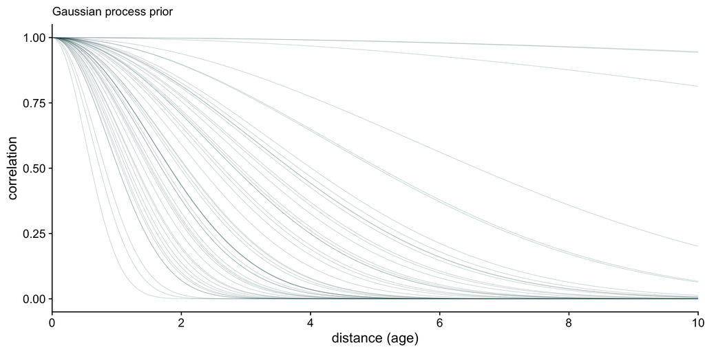

```r
set.seed(11)
nsim = 50
sample_l = invgamma::rinvgamma(nsim, 2.5, 3)
sample_sig = rexp(nsim, 1)

# wrangle into functions
p1 = tibble(
  .draw = 1:nsim,
  l = sample_l,
  sig = sample_sig) %>%
  mutate(sigsq = sig^2,
         rhosq = 1 / (2 * l^2)) %>%
  expand_grid(x = seq(from = 0, to = 10, by = .05)) %>%
  mutate(covariance = sigsq * exp(-rhosq * x^2),
         correlation = exp(-rhosq * x^2)) %>%
  # plot
  ggplot(aes(x = x, y = correlation)) +
  geom_line(aes(group = .draw),
            linewidth = 1/4, alpha = 1/4, color = "#1c5253") +
  scale_x_continuous("distance (age)", expand = c(0, 0),
                     breaks = 0:5 * 2) +
  labs(subtitle = "Gaussian process prior")
p1
```

```r
m3 %>% spread_draws( sdgp_gpage, lscale_gpage )
```

```
# A tibble: 16,000 × 5
   .chain .iteration .draw sdgp_gpage lscale_gpage
    <int>      <int> <int>      <dbl>        <dbl>
 1      1          1     1      0.351         5.65
 2      1          2     2      0.404         6.20
 3      1          3     3      0.538         5.90
 4      1          4     4      0.586        12.8
 5      1          5     5      0.443         2.47
 6      1          6     6      0.387         2.28
 7      1          7     7      0.481         3.33
 8      1          8     8      0.874         4.21
 9      1          9     9      0.799         3.90
10      1         10    10      0.504         3.22
# ℹ 15,990 more rows
```

Here’s our posterior distribution of the Gaussian process

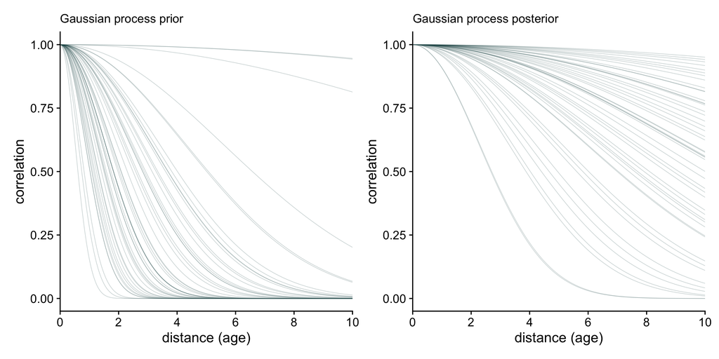

```r
post <- as_draws_df(m3)

# for `slice_sample()`
set.seed(14)

# wrangle
p2 <-
  post %>%
  mutate(sigsq = sdgp_gpage^2,
         rhosq = 1 / (2 * lscale_gpage^2)) %>%
  slice_sample(n = 50) %>%
  expand_grid(x = seq(from = 0, to = 10, by = .05)) %>%
  mutate(covariance = sigsq * exp(-rhosq * x^2),
         correlation = exp(-rhosq * x^2)) %>%

  # plot
  ggplot(aes(x = x, y = correlation)) +
  geom_line(aes(group = .draw),
            linewidth = 1/4, alpha = 1/4, color = "#1c5253") +
  stat_function(fun = function(x)
                  exp(-(1 / (2 * mean(post$lscale_a_gpage)^2)) * x^2),
                color = "#0f393a", linewidth = 1) +
  scale_x_continuous("distance (age)", expand = c(0, 0),
                     breaks = 0:5 * 2) +
  labs(subtitle = "Gaussian process posterior")

p1 + p2
```

```r
m1 <- add_criterion(m1, criterion = "loo")
m2 <- add_criterion(m2, criterion = "loo")
m3 <- add_criterion(m3, criterion = "loo")
loo_compare(`m1: intercept only` = m1, m2, `m3: gaussian process`  = m3)
```

```
                     elpd_diff se_diff
m2                     0.0       0.0
m3: gaussian process  -1.4       1.7
m1: intercept only   -11.8       5.0
```

Let’s plot the model-predicted values as a function of age for models 2 and 3 to see how they compare.

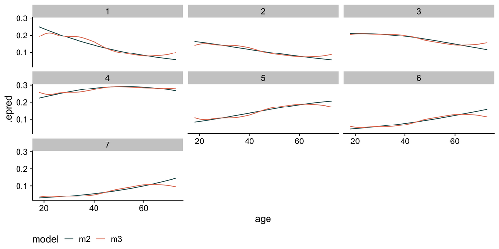

```r
nd = d %>% distinct(age)

pred_m2 = nd %>%
  add_epred_draws(m2) %>%
  mutate(model = "m2")

pred_m3 = nd %>%
  add_epred_draws(m3) %>%
  mutate(model = "m3")

full_join(pred_m2, pred_m3) %>%
  group_by(model, age, .category) %>%
  mean_qi(.epred) %>%
  ggplot( aes( x=age, y=.epred, color=model ) ) +
  geom_line() +
  scale_color_manual(values = c("#1c5253" , "#e07a5f")) +
  facet_wrap(~.category) +
  theme(legend.position = "bottom")
```

If you zoom in on any of these response options, you’ll see that model 2, which modeled age as a linear predictor, only allows for gradual change in our outcome, whereas model 3 allows for some more “wiggliness”.

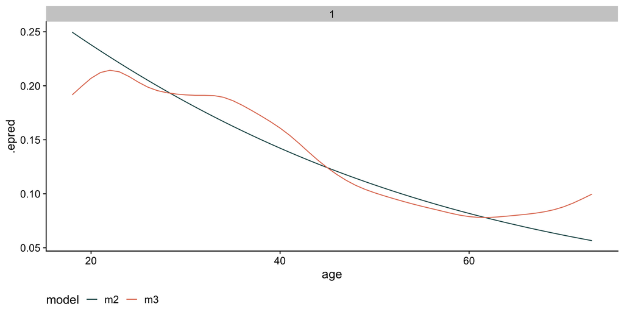

```r
full_join(pred_m2, pred_m3) %>%
  filter(.category %in% c(1)) %>%
  group_by(model, age, .category) %>%
  mean_qi(.epred) %>%
  ggplot( aes( x=age, y=.epred, color=model ) ) +
  geom_line() +
  scale_color_manual(values = c("#1c5253" , "#e07a5f")) +
  facet_wrap(~.category) +
  theme(legend.position = "bottom")
```

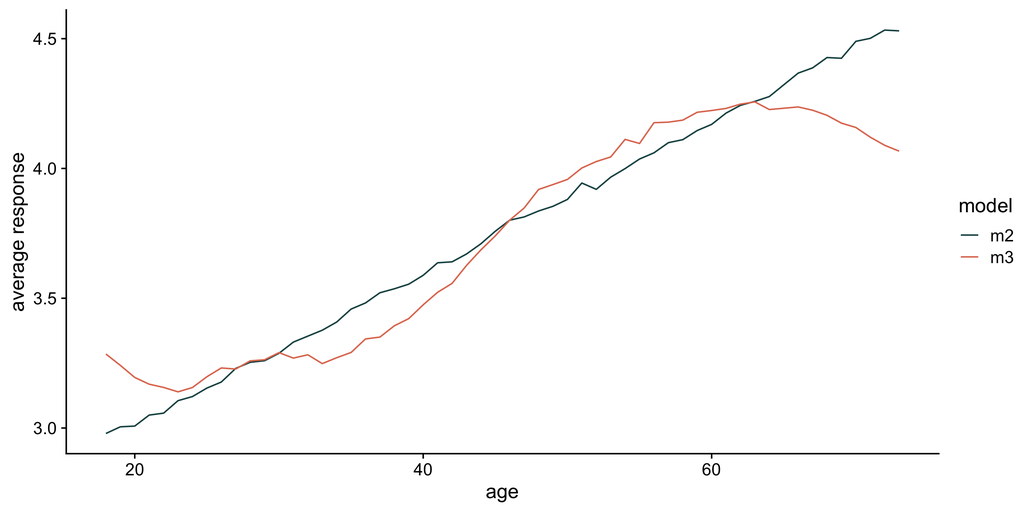

```r
ppd_m2 = nd %>%
  add_predicted_draws(m2) %>%
  mutate(model = "m2")

ppd_m3 = nd %>%
  add_predicted_draws(m3) %>%
  mutate(model = "m3")

full_join(ppd_m2, ppd_m3) |>
  ungroup() |>
  with_groups( c(model, age), summarise, avg = mean( as.numeric(.prediction) ) ) |>
  ggplot( aes( x=age, y=avg, color=model ) ) +
  geom_line() +
  scale_color_manual(values = c("#1c5253" , "#e07a5f")) +
  labs( x="age", y="average response" )
```

```r
nd = expand.grid(
  age=18:72,
  iter=1:50)

plotdata = m3 %>%
  predicted_draws(newdata = d) |>
  filter(.draw <= 50)

  plotdata |>
    mutate(.prediction = as.numeric(.prediction)) |>
  with_groups(
    c(age, .draw), summarise, m = mean(.prediction, na.rm=T)
  ) |>
    ggplot( aes( x=age, y=m, group=.draw) ) +
    geom_line(alpha=.4, color = "#1c5253") +
    geom_vline(aes(xintercept = c(47)), color = "red")
```

[figure not shown]

### model 4: gaussian process with a new kernal

```r
m4 <- brm(
  data = d,
  family = cumulative,
  def ~ 1 + gp(age, cov = "exponential", scale = F),
  prior = c( prior(normal(0, 1.5),    class=Intercept),
             prior(inv_gamma(2.5, 3), class=lscale, coef = gpage),
             prior(exponential(1),    class=sdgp, coef = gpage)),
  iter=5000, warmup=1000, seed=3, cores=4,
  file = here("files/models/m91.4")
)
```

```r
m4
```

```
 Family: cumulative
  Links: mu = logit; disc = identity
Formula: def ~ 1 + gp(age, cov = "exponential", scale = F)
   Data: d (Number of observations: 529)
  Draws: 4 chains, each with iter = 5000; warmup = 1000; thin = 1;
         total post-warmup draws = 16000

Gaussian Process Hyperparameters:
              Estimate Est.Error l-95% CI u-95% CI Rhat Bulk_ESS Tail_ESS
sdgp(gpage)       0.47      0.16     0.22     0.84 1.00     7175     5164
lscale(gpage)    11.93     12.34     1.79    43.70 1.00     7382     5700

Regression Coefficients:
             Estimate Est.Error l-95% CI u-95% CI Rhat Bulk_ESS Tail_ESS
Intercept[1]    -1.93      0.29    -2.56    -1.43 1.00     7301     6968
Intercept[2]    -1.18      0.28    -1.79    -0.70 1.00     7166     6991
Intercept[3]    -0.32      0.27    -0.92     0.15 1.00     7355     5429
Intercept[4]     0.89      0.27     0.29     1.36 1.00     7716     5569
Intercept[5]     1.77      0.29     1.16     2.29 1.00     8373     7331
Intercept[6]     2.73      0.32     2.06     3.32 1.00     9640     6593

Further Distributional Parameters:
     Estimate Est.Error l-95% CI u-95% CI Rhat Bulk_ESS Tail_ESS
disc     1.00      0.00     1.00     1.00   NA       NA       NA

Draws were sampled using sampling(NUTS). For each parameter, Bulk_ESS
and Tail_ESS are effective sample size measures, and Rhat is the potential
scale reduction factor on split chains (at convergence, Rhat = 1).
```

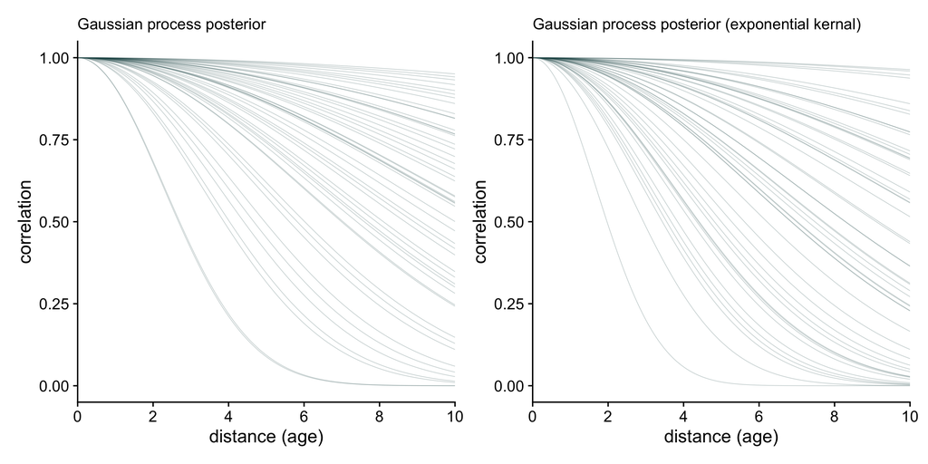

```r
post4 <- as_draws_df(m4)

# for `slice_sample()`
set.seed(14)

# wrangle
p3 <-
  post4 %>%
  mutate(sigsq = sdgp_gpage^2,
         rhosq = 1 / (2 * lscale_gpage^2)) %>%
  slice_sample(n = 50) %>%
  expand_grid(x = seq(from = 0, to = 10, by = .05)) %>%
  mutate(covariance = sigsq * exp(-rhosq * x^2),
         correlation = exp(-rhosq * x^2)) %>%

  # plot
  ggplot(aes(x = x, y = correlation)) +
  geom_line(aes(group = .draw),
            linewidth = 1/4, alpha = 1/4, color = "#1c5253") +
  stat_function(fun = function(x)
                  exp(-(1 / (2 * mean(post4$lscale_a_gpage)^2)) * x^2),
                color = "#0f393a", linewidth = 1) +
  scale_x_continuous("distance (age)", expand = c(0, 0),
                     breaks = 0:5 * 2) +
  labs(subtitle = "Gaussian process posterior (exponential kernal)")

p2 + p3
```

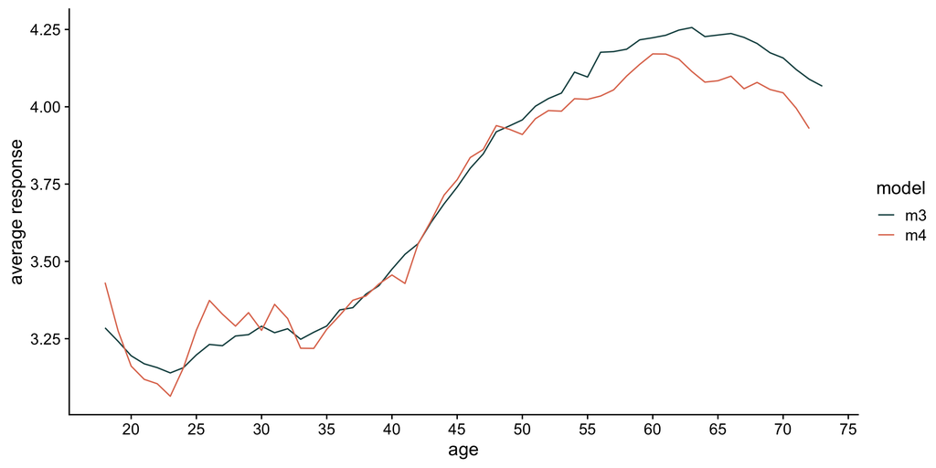

```r
ppd_m4 = nd %>%
  add_predicted_draws(m4) %>%
  mutate(model = "m4")

full_join(ppd_m3, ppd_m4) |>
  ungroup() |>
  with_groups( c(model, age), summarise,
               avg = mean( as.numeric(.prediction) ) ) |>
  ggplot( aes( x=age, y=avg, color=model ) ) +
  geom_line() +
  scale_color_manual(values = c("#1c5253" , "#e07a5f")) +
  labs( x="age", y="average response" ) +
  scale_x_continuous(breaks=seq(20,75,5))
```

## another example

```r
data_path = "https://raw.githubusercontent.com/sjweston/uobayes/refs/heads/main/files/data/external_data/williams.csv"
d <- read.csv(data_path)
rethinking::precis(d)
```

```
                 mean         sd       5.5%      94.5%      histogram
id        98.61029694 63.7493291 10.0000000 207.000000   ▇▇▇▃▅▅▅▃▃▃▂▂
female     0.57016803  0.4950710  0.0000000   1.000000     ▅▁▁▁▁▁▁▁▁▇
PA.std     0.01438236  1.0241384 -1.6812971   1.751466       ▁▁▃▇▇▃▁▁
day       44.17962096 27.6985612  6.0000000  92.000000     ▇▇▇▇▅▅▅▃▃▃
PA_lag     0.01992587  1.0183833 -1.7204351   1.717036     ▁▂▃▅▇▇▅▃▂▁
NA_lag    -0.04575229  0.9833161 -0.8750718   1.990468 ▇▃▂▁▁▁▁▁▁▁▁▁▁▁
steps.pm   0.05424387  0.6298941 -1.0258068   1.011356       ▁▂▇▇▃▁▁▁
steps.pmd  0.02839160  0.7575395 -1.1235951   1.229974 ▁▁▇▇▁▁▁▁▁▁▁▁▁▁
NA.std    -0.07545093  0.9495660 -1.0484293   1.811061     ▁▁▁▇▂▁▁▁▁▁
```

### estimating carry-over effects

```r
m5 <- brm(
  data = d,
  family = gaussian,
  PA.std ~ 1 + gp(day, cov = "exp_quad", scale = F) + (1|id),
  prior = c( prior(normal(0, .1), class=Intercept),
             prior(inv_gamma(2.5, 3), class = lscale, coef = gpday),
             prior(exponential(1), class = sdgp, coef = gpday)),
  iter=10000, warmup=1000, seed=3, cores=4,
  file = here("files/models/m91.5")
)
```

```r
m5
```

```
 Family: gaussian
  Links: mu = identity; sigma = identity
Formula: PA.std ~ 1 + gp(day, cov = "exp_quad", scale = F) + (1 | id)
   Data: d (Number of observations: 13033)
  Draws: 4 chains, each with iter = 10000; warmup = 1000; thin = 1;
         total post-warmup draws = 36000

Gaussian Process Hyperparameters:
              Estimate Est.Error l-95% CI u-95% CI Rhat Bulk_ESS Tail_ESS
sdgp(gpday)       0.27      0.21     0.07     0.84 1.09       26       22
lscale(gpday)    31.03     11.85     8.61    52.75 1.06       44      285

Multilevel Hyperparameters:
~id (Number of levels: 193)
              Estimate Est.Error l-95% CI u-95% CI Rhat Bulk_ESS Tail_ESS
sd(Intercept)     0.80      0.05     0.72     0.89 1.08       35       52

Regression Coefficients:
          Estimate Est.Error l-95% CI u-95% CI Rhat Bulk_ESS Tail_ESS
Intercept    -0.02      0.12    -0.32     0.16 1.08       30       24

Further Distributional Parameters:
      Estimate Est.Error l-95% CI u-95% CI Rhat Bulk_ESS Tail_ESS
sigma     0.60      0.00     0.59     0.60 1.01      202      465

Draws were sampled using sampling(NUTS). For each parameter, Bulk_ESS
and Tail_ESS are effective sample size measures, and Rhat is the potential
scale reduction factor on split chains (at convergence, Rhat = 1).
```

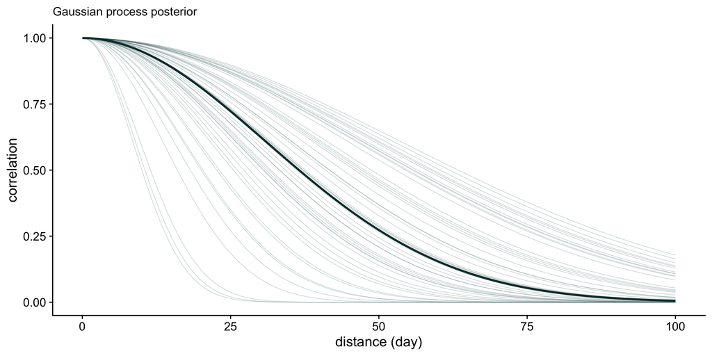

```r
post <- as_draws_df(m5)

# for `slice_sample()`
set.seed(14)

# wrangle
post %>%
  mutate(sigsq = sdgp_gpday^2,
         rhosq = 1 / (2 * lscale_gpday^2)) %>%
  slice_sample(n = 50) %>%
  expand_grid(x = seq(from = 0, to = 100, by = .05)) %>%
  mutate(covariance = sigsq * exp(-rhosq * x^2),
         correlation = exp(-rhosq * x^2)) %>%

  # plot
  ggplot(aes(x = x, y = correlation)) +
  geom_line(aes(group = .draw),
            linewidth = 1/4, alpha = 1/4, color = "#1c5253") +
  stat_function(fun = function(x) exp(-(1 / (2 * mean(post$lscale_gpday)^2)) * x^2),
                color = "#0f393a", linewidth = 1) +
  scale_x_continuous("distance (day)") +
  labs(subtitle = "Gaussian process posterior")
```